# More than counting pixels – perspectives on the importance of remote sensing training in ecology and conservation - Bernd - 2017 - Remote Sensing in Ecology and Conservation - Wiley Online Library

[Remote Sensing in Ecology and Conservation](https://zslpublications.onlinelibrary.wiley.com/journal/20563485)

[Volume 3, Issue 1](https://zslpublications.onlinelibrary.wiley.com/toc/20563485/2017/3/1)

[figure not shown]

Interdisciplinary Perspectives

Open Access

# More than counting pixels – perspectives on the importance of remote sensing training in ecology and conservation

[Asja Bernd](https://zslpublications.onlinelibrary.wiley.com/action/doSearch?ContribAuthorStored=Bernd%2C+Asja)

[Daniela Braun](https://zslpublications.onlinelibrary.wiley.com/action/doSearch?ContribAuthorStored=Braun%2C+Daniela)

[Antonia Ortmann](https://zslpublications.onlinelibrary.wiley.com/action/doSearch?ContribAuthorStored=Ortmann%2C+Antonia)

[Yrneh Z. Ulloa‐Torrealba](https://zslpublications.onlinelibrary.wiley.com/action/doSearch?ContribAuthorStored=Ulloa-Torrealba%2C+Yrneh+Z)

[Christian Wohlfart](https://zslpublications.onlinelibrary.wiley.com/action/doSearch?ContribAuthorStored=Wohlfart%2C+Christian)

[Alexandra Bell](https://zslpublications.onlinelibrary.wiley.com/action/doSearch?ContribAuthorStored=Bell%2C+Alexandra)

First published: 14 September 2016

https://doi.org/10.1002/rse2.27

Citations: 4

## Abstract

As remote sensing (RS) applications and resources continue to expand, their importance for ecology and conservation increases – and so does the need for effective and successful training of professionals working in those fields. Methodological and applied courses often form part of university curricula, but their practical and long‐term benefits only become clear afterwards. Having recently received such training in an interdisciplinary master's programme, we provide our perspectives on our shared education. Through an online survey we include experiences of students and professionals in different fields. Most participants perceive their RS education as useful for their career, but express a need for more training at university level. Hands‐on projects are considered the most effective learning method. Besides methodological knowledge, soft skills are clear gains, including problem solving, self‐learning and finding individual solutions, and the ability to work in interdisciplinary teams. The largest identified gaps in current RS training concern the application regarding policy making, methodology and conservation. To successfully prepare students for a career, study programmes need to provide RS courses based on state‐of‐the‐art methods, including programming, and interdisciplinary projects linking research and practice supported by a sound technical background.

## Introduction

Remote sensing (RS) as well as Geographical Information Systems (GIS) have proven to be highly valuable tools in both ecology (Pettorelli et al. 2011; Skidmore et al. 2011; Anderson and Gaston 2013) and conservation science (Scott et al. 1993; Rodrigues et al. 2004; Pettorelli et al. 2014). Their applicability includes habitat assessments (McDermid et al. 2009; Kuenzer et al. 2011), mapping of ecosystem processes and functioning (Cabello et al. 2012) as well as services (De Araujo Barbosa et al. 2015), animal movement analysis (Kays et al. 2015), conservation planning (Nagendra et al. 2013) and future global earth observations monitoring the state of ecosystems and biodiversity (O'Connor et al. 2015; Skidmore et al. 2015). For research and practice using RS data, GIS are crucial, providing powerful tools to create knowledge and communicate it effectively for policy and decision making.

The growing relevance and rapid development of remote sensing in relation to conservation and ecology within academia can be demonstrated through the change in number of scientific publications over the years. The search string *“remote sensing” AND [conservation OR ecology]* yielded 8147 results in the database SCOPUS starting in the year 1966, 90% of which have been published since 1998, and 53% within the last 5 years (Fig. 1, and Appendix S1 for details).

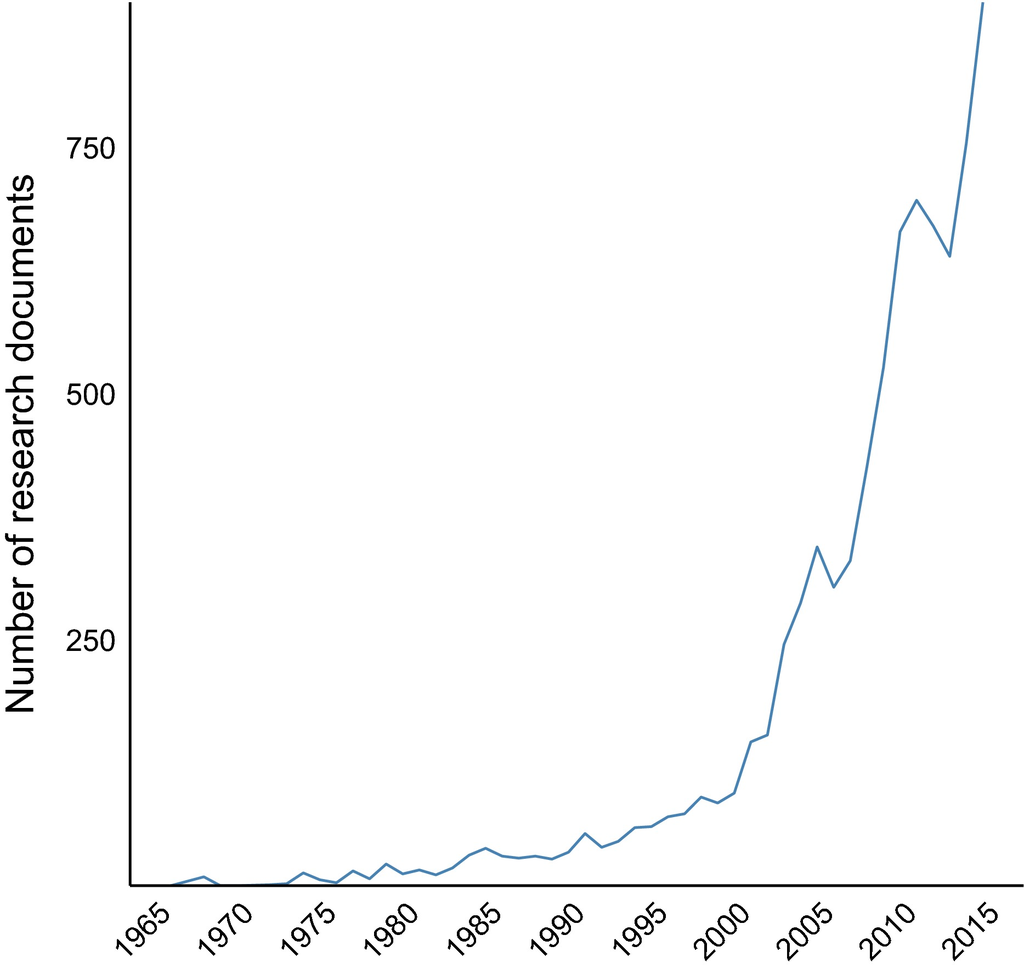

**Figure 1**

Open in figure viewer[PowerPoint](https://zslpublications.onlinelibrary.wiley.com/action/downloadFigures?id=rse227-fig-0001&doi=10.1002%2Frse2.27)

The number of scientific texts published from 1960 to 2015 on remote sensing for ecology or conservation, based on a search of the database SCOPUS (see Appendix S1 for details).

These quickly developing research fields require trained graduates who are able to apply these tools meaningfully to support decision making and answer relevant questions. High‐quality education enables students with technical knowledge and the ability to apply RS results in different contexts, such as policy, academia, conservation or governmental agencies. While methodological courses are often part of university study programmes, their practical and long‐term benefits only become clear afterwards.

Following shared education, we provide our perspectives on graduate and postgraduate training on RS, including GIS, and how it is useful in our diverse working environments in‐ and outside academia. We first explore the obtained skills, both in terms of sound technical and methodological knowledge, as well as soft skills. Secondly, we outline gaps where training in RS and other kind of spatial data analysis could still be improved, and where academic education should place a higher emphasis on. We underline our own experience with an online survey that we conducted aiming at broadening and supporting our insights through the experience of other professionals and students who use RS and GIS in relation to RS for their research and work. Finally, we look towards the future and highlight the opportunities we see for the development of RS training in ecology and conservation.

## Survey

As our shared education shapes our experience, we include the perspectives of professionals and students from different backgrounds through an online survey. This survey was distributed through closed mailing lists of universities and conservation groups, namely those for the study programme Global Change Ecology (University of Bayreuth), University of Cambridge Conservation Research Institute, and the training courses AniMove, Spatio‐Temporal Data Analysis using Free and Open Source Software (Spatial Ecology, UK) and the Module on International Nature Conservation (German Federal Agency for Nature Conservation), with a total of 73 participants. Despite the limited reach, responses stemmed from all six continents (Fig. 2A), although with a heavy focus on the Global North. Most participants received their training in the UK (28), Germany (17) and US (10), with fewer from many other countries. Respondents are mostly working in research‐oriented environments (61.1%), primarily as PhD students (31.2%) and research assistants (18.2%) (Fig. 2B). Early and mature researchers (graduate students, 9.1% and professors, 2.6%) are not highly represented. Respondents are also engaged as consultants (16.9%) and project managers (7.8%) as well as other fields (14.3%). In accordance with this, participants work mostly in universities (38.5%), followed by NGOs (25.3%), research institutes and international organizations (both 16.5%) (Fig. 2C). Only small fractions are employed by companies (2.2%) or government agencies (1.1%). The majority of respondents (90.4%) currently apply the knowledge and skills learnt during their education and training in RS in their research or work in a conservation context. This is consistent with the field of specialization sampled, where keywords like “ecology” and “conservation” were the most prominent, followed by others, such as “biodiversity”, “GIS”, “remote sensing”, “biology” and, to a lesser extent, “landscape”, “mapping”, “wildlife”, “ecological” and “marine” (Fig. 3). Further fields show low numbers. These keywords illustrate in which contexts the community sampled applies RS tools. We included GIS as a means to work with RS data in the survey; when mentioning it, we do not refer to GIS in general, but specifically to its applicability for remote sensing‐based research and practice.

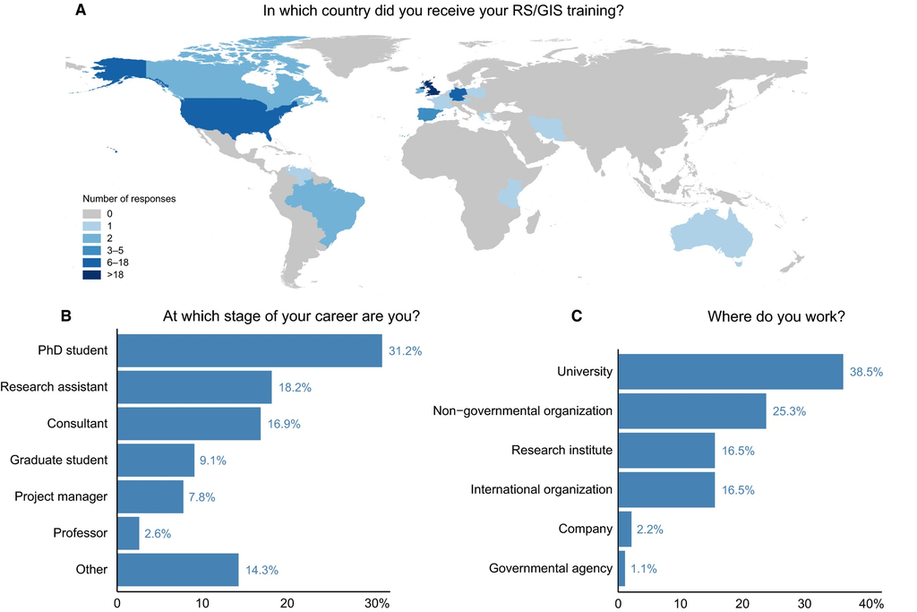

**Figure 2**

Open in figure viewer[PowerPoint](https://zslpublications.onlinelibrary.wiley.com/action/downloadFigures?id=rse227-fig-0002&doi=10.1002%2Frse2.27)

(A) Countries in which respondents received their remote sensing (RS)/Geographical Information Systems (GIS) education (multiple answers possible), (B) professional background of the survey participants and (C) workplaces of the survey participants.

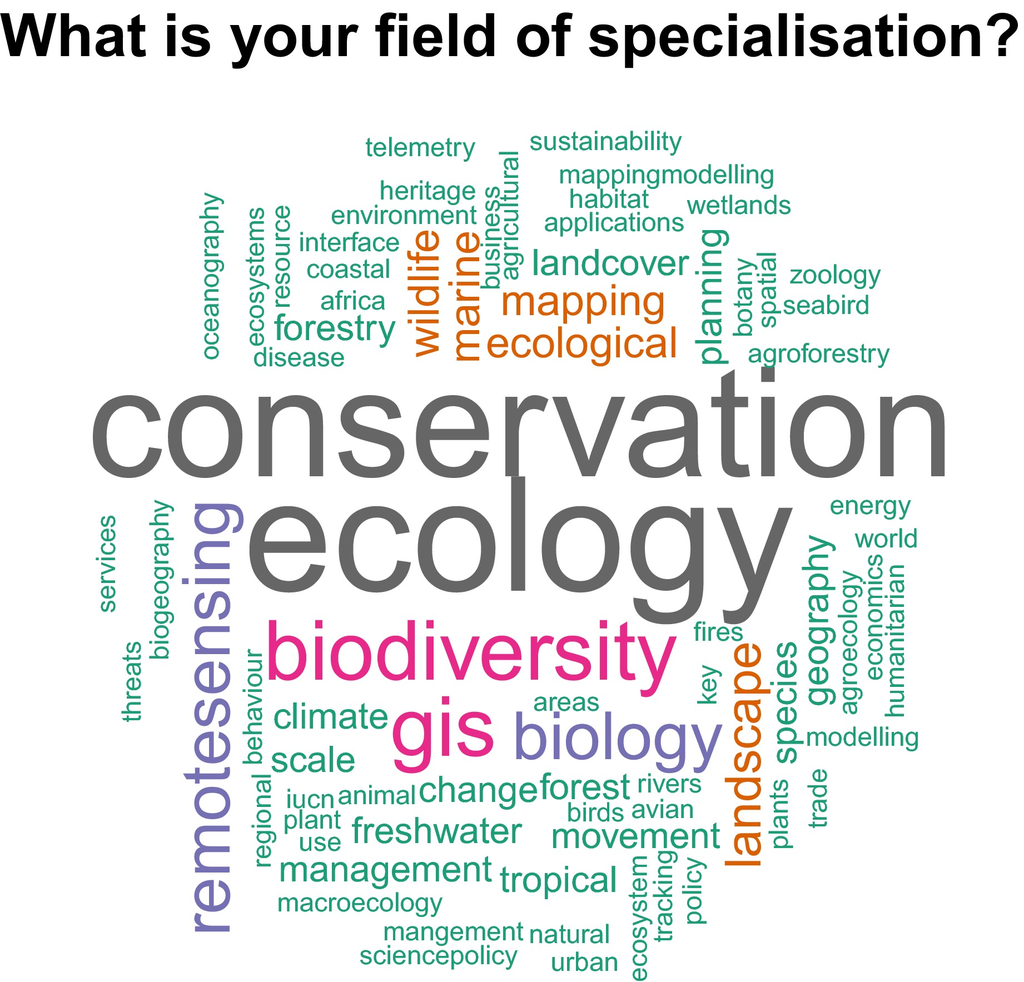

**Figure 3**

Open in figure viewer[PowerPoint](https://zslpublications.onlinelibrary.wiley.com/action/downloadFigures?id=rse227-fig-0003&doi=10.1002%2Frse2.27)

Fields of work by frequency of occurrence (font size).

## Methodological Learnings

Introductory courses in RS convey knowledge about the basic theory of the field. They focus on terminology and data types, different sensors acquiring airborne and space‐borne imagery, as well as how to analyse the data and the different products available. These courses are usually integrated in the methods section of the university curriculum. To this end, this theory‐driven part of the education is centred on the methodological applications, while also demonstrating the huge potential of RS for diverse applications ranging from animal conservation to land management and urban planning.

Basing courses on the use of free and open‐source software is cost‐efficient and crucial for showing its values and importance of encouraging its use. It enables users to control each step of their work, increases transparency (Steiniger and Hunter 2013), fosters joint development, collaboration and the establishment of communities (Steiniger and Hay 2009). Moreover, it also allows people with limited resources (i.e., lower capacity to afford costly licenses) to be at the forefront of innovation and on an equal footing in terms of software utilization for their work (Kogut and Metiu 2001), if the necessary computational resources are available.

Besides a sound knowledge in theory, hands‐on projects have proven to be most helpful to complement RS training and education in our experience. Courses are more valuable when applying methodological skills in a specific research setting and can especially benefit from the collaboration of lecturers from different disciplines, resulting, for example in the use of RS data for ecosystem service analysis, or species distribution modelling. Furthermore, hands‐on projects are more likely to involve understanding, modifying and creating large datasets, honing crucial skills in handling them. This is reflected in the higher importance of university seminars compared to lectures in our survey results (Fig. 4A).

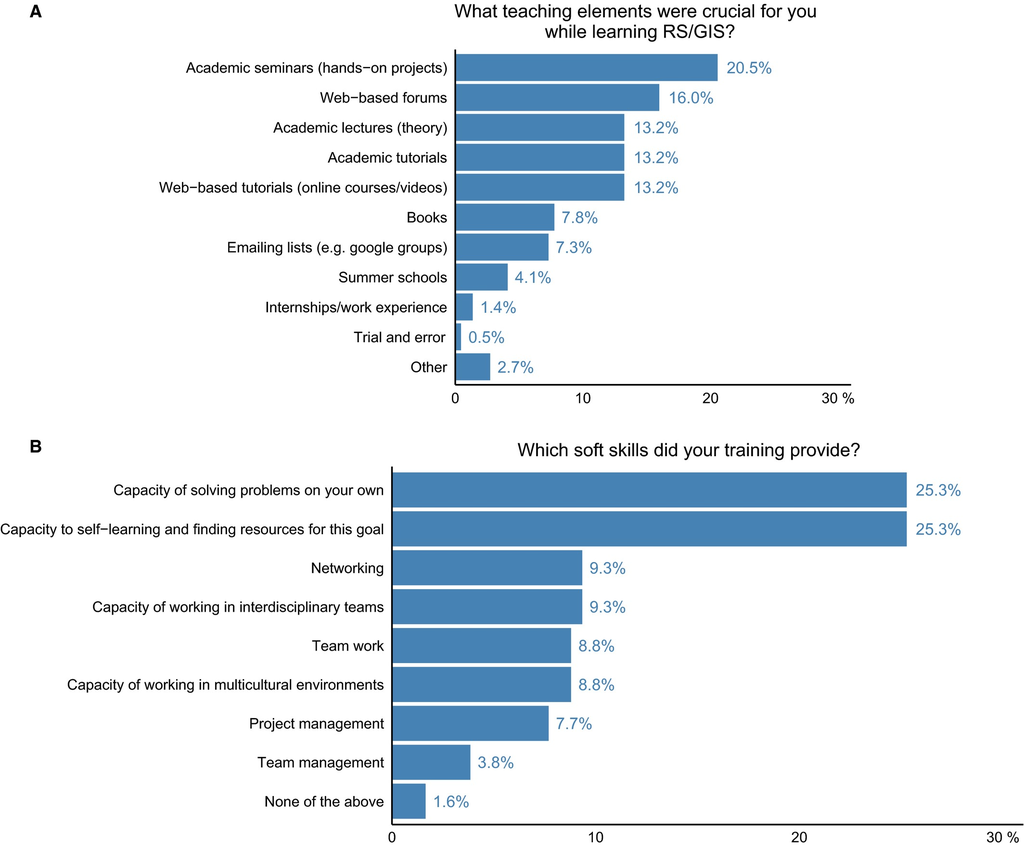

**Figure 4**

Open in figure viewer[PowerPoint](https://zslpublications.onlinelibrary.wiley.com/action/downloadFigures?id=rse227-fig-0004&doi=10.1002%2Frse2.27)

(A) Importance of teaching elements as perceived by interviewee (multiple answers possible) and (B) soft skills obtained during the training (multiple answers possible).

Although RS is known to reduce the amount of data collected in the field, often ground data are necessary to calibrate and validate RS‐derived analyses (Fuller et al. 1998; Ceccato et al. 2002; Congalton and Green 2008; Müller and Brandl 2009). Thus, being able to plan and conduct fieldwork to generate accurate RS products is very important. Such practical examples can be implemented in field classes. This allows discussing appropriate data needed and their acquisition (e.g. type and number of plots) in a study site to answer research questions. Conducting field campaigns to collect data such as vegetation or land cover information is valuable to gain understanding of on‐site conditions and how they may or may not be reflected in remotely sensed information. This experience can enable to responsibly weigh the benefits and limits of RS research in later real‐life projects.

Learning, however, is not limited to the university. Opportunities to gather knowledge outside specific study programmes already exist, such as during scientific summer (or winter) schools, which are already part of some university curricula. Especially in the field of RS, there are many available. Attending these courses provides multiple benefits in our experience: it allows students to focus on specific topics of interest, also those outside their university curriculum; it brings together scientists, practitioners and students from different fields, which fosters interdisciplinary collaboration and networking, and it allows for a broader perspective of applications and methods.

The results of the survey confirm the application of all the above‐mentioned learning strategies of RS and GIS. The learning process is mainly achieved through university courses (43.3%) and self‐teaching (34.6%), whereas internships (12.6%) and science summer schools (9.4%) are less common knowledge sources (Fig. 5). However, the perception which of these methods are considered crucial during the training is slightly different: academic seminars (20.5%), web‐based forums and tutorials (16.0% and 13.2%, respectively), lectures (13.2%) and academic tutorials (13.2%) are regarded as most important, followed by books (7.8%), emailing lists (7.3%) and summer schools (4.1%). Experiences gained independently (e.g. trial and error, 0.5%) and in working environments (e.g. internships, 1.4%) were rarely regarded as crucial learning sources (Fig. 4A). Importantly though, the opportunities to participate in schools or internships can depend on the financial situation of students and may not be accessible to all.

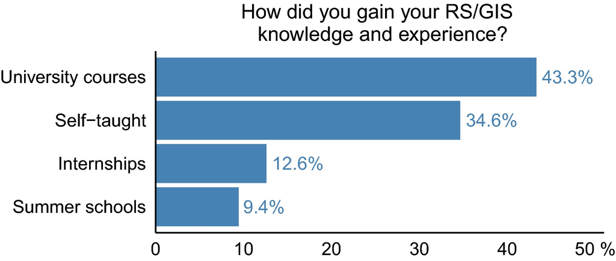

**Figure 5**

Open in figure viewer[PowerPoint](https://zslpublications.onlinelibrary.wiley.com/action/downloadFigures?id=rse227-fig-0005&doi=10.1002%2Frse2.27)

Remote sensing (RS)/Geographical Information Systems (GIS) education history of survey participants.

## Soft Skills Gained Through RS Training

Besides learning the theory and application, further relevant skills are acquired and developed during the time of training and complement it (Fig. 4B). Among these are capacity for problem‐solving, confidence in the ability to learn, networking, project management as well as interdisciplinary and intercultural skills.

Solution‐oriented thinking and problem‐solving skills are fundamental when working with RS data, and are considered some of the most important components of “critical and structured thinking” in general (Schulz 2008). This pattern is reflected in the survey: the capacity of solving problems on one's own (25.3%) and to self‐learn and find resources (25.3%) are the most common soft skills gained from RS and GIS education. In comparison, teamwork, project and team management, capacity of working in multicultural and multidisciplinary teams and networking, among others, were considered secondary skills. These competences are highly valuable generally, not only in academia. Study programmes fostering them are therefore crucial in preparing students for successful careers (Schulz 2008; Heckman and Kautz 2012).

The many options of RS in terms of data and methods can make problem solving complex. The availability of approaches requires creativity from students to find their own way and discuss options during group projects. This capacity of developing an appropriate solution to the respective question in an original and empirical way is fostered during RS training in individual projects. Both as groups and individuals, students have to learn this. Resources we found highly useful can be setting up lessons for solving problems, such as programming issues, exchanging information in topic‐related emailing lists, searching in the vast numbers of online forums for solutions (e.g. [www.gis.stackexchange.com](http://www.gis.stackexchange.com/)) and educating themselves through online tutorials (e.g. [www.r-bloggers.com](http://www.r-bloggers.com/), also videos on YouTube and other channels), manuals (R: www.cran.r-project.org/manuals.html, GRASS: http://grass.osgeo.org/documentation/manuals/, QGIS: http://qgis.org/en/docs/index.html) and books available through libraries or for purchase.

Another crucial aspect is the confidence in one's own ability to learn. When RS training adequately increases in difficulty over time and includes big datasets and real world data and questions, it helps students develop trust in their own ability to grow and find solutions to new challenges, even if they may seem daunting at first.

More generally, working with people from diverse backgrounds provides advantages in RS training and is considered as comparatively important in the survey. Interdisciplinary and international environments generate an enriching learning experience. Students can benefit from a mixture of diverse perspectives, ideas, solutions and expertise. Being able to learn from each other, and from students with more knowledge in certain fields, allows seeing a range of possibilities and finding a comfortable environment to ask questions no matter how basic.

Two important general learnings are project planning and management. These are practiced as most of the course assignments are set up as projects – developed and conducted individually or in small groups. Setting up a project requires all necessary steps from literature search, identifying a research question, to planning and dividing tasks, all through discussions with fellow students, which is valuable and important (Schulz 2008; Heckman and Kautz 2012).

Lastly, even if the next career steps are not directly in the field of RS, the training provides the knowledge to estimate on the usefulness and feasibility of RS applications for projects. This is of particular advantage for conservation projects where knowledge about RS is limited on site. Although RS may seem like an ideal solution to technical, educational and institutional impediments hindering research on the ground (Jha and Chowdary 2007), the opportunities and limitations need to be understood, and its applicability evaluated. The skills acquired during RS training foster the ability to assess planned projects and provide insights for people from different backgrounds.

## Usefulness of RS Training in Different Contexts

While these soft skills are crucial in many work settings irrespective of the field, the methodological knowledge also provides clear advantages. 83.6% of the survey respondents consider their RS and GIS skills as helpful or very helpful for their career, for 74.0% it plays a role for their research and 71.2% perceive their RS and GIS knowledge helpful for their research (Fig. 6B). For 69.9% of the participants their RS and GIS skills have been useful in conservation applications, however, only for 31.5% the same can be said in a policy context.

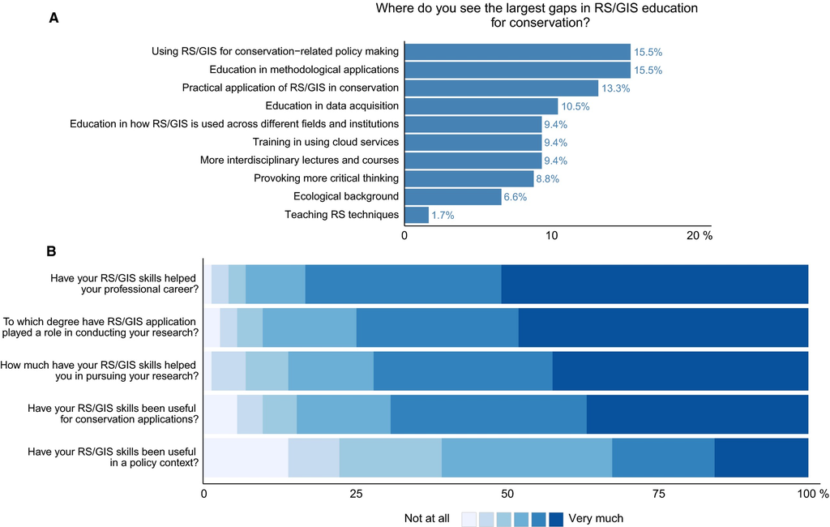

**Figure 6**

Open in figure viewer[PowerPoint](https://zslpublications.onlinelibrary.wiley.com/action/downloadFigures?id=rse227-fig-0006&doi=10.1002%2Frse2.27)

(A) Largest perceived gaps in remote sensing (RS)/Geographical Information Systems (GIS) education for conservation (multiple answers possible) and (B) usefulness and relevance of RS/GIS training for policy, research and practice.

As the ways of distributing the survey likely created a bias towards people working in academia, the results indicate a higher usefulness of RS and GIS skills in research than in the other fields. The low perception and application of RS and GIS in a policy context could partially stem from the comparative novelty of both as tools in this field and from a lacking focus on the effective communication of results during training. Professionals with a comprehensive and interdisciplinary RS training can fill this gap and foster the application in such areas.

## Gaps and Needs

The wish list for effective academic training is infinite, and not everything can be covered in graduate or postgraduate training. However, there are fundamental issues that academic training should aim to achieve: the high number of respondents in the survey relying on self‐teaching and non‐academic help sources likely indicates a large demand for training or assistance in general. This is supported by the participants asking for teaching with a focus on methodological and practical applications (15.5% and 13.3%, respectively) (Fig. 6A). They also identify further gaps in current training, especially regarding applications in conservation‐related policy making (15.5%) (Fig. 6A), thus indicating the wish to address the lower applicability of RS and GIS for policy making described above (Fig. 6B). Besides data access and acquisition, interdisciplinarity, linking technology, methodology and context, state‐of‐the‐art methods, stakeholder involvement, adequate supervision and the creation of support networks play important roles.

### State‐of‐the‐art training

Career perspectives are shaped by the methods graduates have been introduced to during their studies. State‐of‐the‐art training is elemental and should not be defined by the specific research at a university but by what students need to succeed. Especially interdisciplinary study programmes cannot teach all aspects of RS simultaneously with their programme content. Nevertheless, RS training should include up‐to‐date methods such as applications of unmanned aerial vehicles (UAVs) due to their lower costs in comparison to high‐resolution imagery (Koh and Wich 2012) and programming languages such as R (already well established in ecology) or Python. While Graphical User Interfaces (GUI) provide a smoother start (Amatulli et al. 2014), programming skills have proven very important for processing big datasets and making research collaborative and replicable through sharing of code. Furthermore, students benefit by gaining flexibility in writing new codes and finding problem solutions, and gain access to cluster or cloud computing facilities. Teaching cloud computing has also been identified as a gap in the survey (9.4%), and should include both functionalities and limits, especially regarding freely accessible cloud‐based services.

### Data availability and access

Remote sensing provides very diverse products, which has pros and cons when searching for suitable Earth observation data. While new spatial datasets are becoming available every day, tracking what is out there and where to find useful data for one's project is one of the most important skills, and is regarded as a gap by 10.5% of survey respondents. Remotely sensed data from a multitude of sensors with different spatial and temporal resolutions are freely accessible, as well as environmental (e.g. climatic or hydrological) data. The IUCN Red List of Threatened Species and the Global Biodiversity Information Facility (GBIF) provide data on species occurrence. Increasingly, also processed products are available, ranging from ecoregion maps (Olson et al. 2001) or biodiversity hotspot maps (Myers et al. 2000) to Hansen et al.'s (2013) global deforestation data. An overview over what exists, how already processed data can (or cannot) be used, and where their chances and limits are, is a crucial aspect of training. This includes learning to judge which data are applicable for the ecological problem in question, and to assess the uncertainties and limitations of datasets, such as the accuracy of global datasets at regional scale. At the same time, not all available data come free of charge, an issue known to affect conservation (Turner et al. 2015), limiting teaching opportunities and thus students’ experiences. Therefore, we strongly echo the call for more freely available data to lay the foundations for successful conservation early on.

### Interdisciplinarity

Next to the basis in RS, an understanding of ecology and conservation approaches is necessary. The link between the method, its application and the ultimate goal is sometimes lacking, and even institutionalized. Traditionally, professorships are often awarded for either RS or conservation, and therefore courses offered by these lecturers mostly focus on one or the other. Joint courses, offered by several departments, might require more preparation efforts. However, if well prepared, they pay off through project work that allows students to engage in meaningful topical work, and can help decrease institutional barriers. This was also recognized in the survey, with respondents lacking interdisciplinary lectures and courses (9.4%), knowledge of the use of RS and GIS across fields (9.4%) and the ecological background (6.6%),

Furthermore, the variety of ways in which spatial data can inform conservation should be reflected in the lecture hall. While it is clear that not every method can be taught in detail, a diverse presentation of the many different applications of GIS and RS within a larger conservation context should be striven for.

### Linking research and practice

A part of this context should also concern the world outside of academia. Conservation, and especially conservation research, has been recognized to have occurred in a bubble, with developed methods lacking implementation in the field (Knight et al. 2008). We therefore call for courses bringing together different fields of research as well as practitioners, and addressing technical as well as social and economic aspects. Discussing all steps of a real‐world conservation project and how spatial conservation data and methods feed into it exemplifies the link of research and practice. This also needs to include a critical discussion of methods and concepts to avoid people thinking in pixels and data only. Real‐world projects such as during internship placements reveal the importance of and approaches for cooperating with local institutions or stakeholders, and create benefits through stakeholder knowledge (Brown 2002; Turnhout et al. 2012). Cooperation with local partners can thus make scientific research applicable and create an effect outside of science (Thackway et al. 2013). Lastly, such approaches foster networking skills, a generally regarded essential asset (Schulz 2008; Parsons et al. 2014).

Furthermore, our survey indicated a low applicability of RS in policy contexts and respondents expressed their wish to learn more about the use of RS for conservation‐related policy making (15.5%), a highly interdisciplinary aspect. This should comprise also the communication to non‐experts, and how to translate data into information. Discussion of impacts and the link between conservation and relevant stakeholders, and how to engage with them, should at least be touched upon or resources be recommended.

### Supervision

Lecturers and tutors can provide crucial support in equipping students with the skills discussed. Learning RS and using it to answer complex research questions can be challenging in our experience, and students may feel lost if they do not receive the supervision needed in independent projects. Thus, it is important to break down the complexity and tasks into feasible steps. Supervision should further provide help for self‐help, and according to our survey more critical thinking (8.8%).

Also, supervisors need to be aware of gender bias as remote sensing training is a part of academia where social disparities are reflected and well documented (Madera et al. 2009; Moss‐Racusin et al. 2012; Roth et al. 2012; Knobloch‐Westerwick et al. 2013). It is important that female students are adequately supported to pursue their interests and develop confidence just as much as their male counterparts.

### Advanced and continuous learning

Lastly, while this article focuses on graduate and postgraduate education, learning does not stop there. First, not everything can be included in university courses, especially in interdisciplinary programmes. Second, the complexity and wide range of applications of RS make it necessary to keep pace with newly emerging technologies and methods. Training continues after graduation, when young professionals apply and broaden their knowledge in their job. Therefore, more advanced courses that cover specific interests should be offered, not only at the academic level but also for the other kinds of users.

## Conclusion

The perspectives provided here cannot be exhaustive given our own shared education and the bias of survey respondents both towards academia and the Global North. Based on our diversity of backgrounds and working experiences, we consider resource availability and capacity crucial issues in many countries. These basic needs are a prior requirement to the ideas discussed in this article and our concluding messages.

What do we want RS education for ecology and conservation to be like? In our perspective, the single biggest answer to this is goal oriented. Developing courses should be focused on the questions: where should students be able to work and what skills do they need to get there? A state‐of‐the‐art, future‐oriented training integrating methodology, technology and context forms the basis for this in our eyes. It is crucial to break down the complexity of spatial analyses, so that students develop confidence and strategies to deal with challenges. Training should include field courses or the opportunity for scientific summer schools to provide more realistic experiences. Interdisciplinary and international environments will foster crucial skills and can help to create new perspectives and ideas. A basis of broad general skills and opportunities to specialize according to individual interests would enable students to develop their own skill sets and profiles. Admittedly, we describe a perfect world, and as Eduardo Galeano put it, *utopia can never be reached – its purpose, however, is to make us walk forward* (Galeano 2001).

## Acknowledgements

We wish to thank Martin Wegmann for encouragement and critical and helpful comments, and Daniel Kachelriess, Katrin Ziewers and Andrea Hess, as well as two anonymous reviewers, for valuable input and suggestions. Further we would like to thank the respondents of our survey and everyone helping us to distribute the survey. The international study programme Global Change Ecology (M.Sc.) at the University of Bayreuth, where we received our training, strongly shaped our perspective. This publication was funded by the German Research Foundation (DFG) and the University of Bayreuth in the funding programme Open Access Publishing.

## Data accessibility

The results of our survey can be accessed on:

http://dx.doi.org/10.5281/zenodo.49870

The results of the literature search can be accessed on:

http://dx.doi.org/10.5281/zenodo.58586

## Citing Literature

[figure not shown]

[Volume3, Issue1](https://zslpublications.onlinelibrary.wiley.com/toc/20563485/2017/3/1)

[Special Issue: Training in Remote Sensing](https://zslpublications.onlinelibrary.wiley.com/toc/20563485/2017/3/1)

March 2017

Pages 38-47

### Metrics

- Citations: 4

### Details

  © 2016 The Authors. *Remote Sensing in Ecology and Conservation* published by John Wiley & Sons Ltd.

  This is an open access article under the terms of the [Creative Commons Attribution‐NonCommercial](http://creativecommons.org/licenses/by-nc/4.0/) License, which permits use, distribution and reproduction in any medium, provided the original work is properly cited and is not used for commercial purposes.

### Keywords

  - [Academic education](https://zslpublications.onlinelibrary.wiley.com/action/doSearch?field1=Keyword&text1=Academic%20education)
  - conservation
  - [GIS](https://zslpublications.onlinelibrary.wiley.com/action/doSearch?field1=Keyword&text1=%0AGIS%0A)
  - [online survey](https://zslpublications.onlinelibrary.wiley.com/action/doSearch?field1=Keyword&text1=online%20survey)
  - [remote sensing](https://zslpublications.onlinelibrary.wiley.com/action/doSearch?field1=Keyword&text1=remote%20sensing)
  - training

### Funding Information

  - German Research Foundation (DFG)
  - University of Bayreuth

### Publication History

  - Issue Online: 20 March 2017
  - Version of Record online: 14 September 2016
  - Manuscript accepted: 01 August 2016
  - Manuscript revised: 25 July 2016
  - Manuscript received: 22 April 2016

[Download PDF](https://zslpublications.onlinelibrary.wiley.com/doi/pdf/10.1002/rse2.27)

back